# DATA 607 Final Project: Predicting Financial Well Being

## Federal Reserve

```r
# select independent variables
#fed_df <- fed_df %>% select(cfpb_score, econ_saving, econ_fin_ok, econ_pay_exp400, econ_skip_med, edu, credit_guess) #0.4379

fed_df <- fed_df %>% select(cfpb_score, age, age_7cat, econ_saving, econ_inc_4cat, econ_fin_ok, econ_pay_exp400, econ_skip_med) #0.4675

# split data
fed_split <- initial_split(fed_df, prop = 0.8, strata = cfpb_score)
fed_training <- training(fed_split)
fed_test <- testing(fed_split)
```

```r
# Fitting to Trained Data
lm_fit <- lm_model %>%
          fit(cfpb_score ~ ., data = fed_training)


# Explore Training Results
names(lm_fit)
```

```
## [1] "lvl"     "spec"    "fit"     "preproc" "elapsed"
```

```r
summary(lm_fit$fit)
```

```
##
## Call:
## stats::lm(formula = cfpb_score ~ ., data = data)
##
## Residuals:
##     Min      1Q  Median      3Q     Max
## -34.135  -6.788  -0.738   6.466  32.090
##
## Coefficients:
##                                Estimate Std. Error t value Pr(>|t|)
## (Intercept)                    45.45928    1.78738  25.433  < 2e-16 ***
## age                             0.15135    0.06205   2.439  0.01477 *
## age_7cat25-34                  -3.21769    1.00635  -3.197  0.00140 **
## age_7cat35-44                  -5.44628    1.43514  -3.795  0.00015 ***
## age_7cat45-54                  -5.78081    1.98014  -2.919  0.00353 **
## age_7cat55-64                  -6.39763    2.50266  -2.556  0.01062 *
## age_7cat65-74                  -3.12727    3.07008  -1.019  0.30846
## age_7cat75+                    -3.38188    3.71940  -0.909  0.36328
## econ_saving$1,000,000 or more   7.32404    0.81005   9.042  < 2e-16 ***
## econ_saving$100,000 - $249,999  1.20829    0.69505   1.738  0.08223 .
## econ_saving$250,000 - $499,999  1.69734    0.77751   2.183  0.02911 *
## econ_saving$50,000 - $99,999    0.04141    0.72572   0.057  0.95450
## econ_saving$500,000 - $999,999  3.39762    0.82441   4.121 3.86e-05 ***
## econ_savingNot sure             2.26184    1.18522   1.908  0.05643 .
## econ_savingRefused              1.99110    1.41009   1.412  0.15804
## econ_savingUnder $50,000       -1.64144    0.54485  -3.013  0.00261 **
## econ_inc_4cat$25,000-$49,999   -4.33619    0.62143  -6.978 3.64e-12 ***
## econ_inc_4cat$50,000-$99,999   -2.34490    0.50138  -4.677 3.03e-06 ***
## econ_inc_4catLess than $25,000 -3.31709    0.64475  -5.145 2.84e-07 ***
## econ_inc_4catRefused           -3.25108    2.20784  -1.473  0.14098
## econ_fin_okRefused             15.95144    5.23388   3.048  0.00232 **
## econ_fin_okYes                 10.94248    0.60587  18.061  < 2e-16 ***
## econ_pay_exp400Refused          4.54400    2.63361   1.725  0.08456 .
## econ_pay_exp400Yes              5.75951    0.52473  10.976  < 2e-16 ***
## econ_skip_medRefused           -1.36292    2.60536  -0.523  0.60093
## econ_skip_medYes               -6.58096    0.53583 -12.282  < 2e-16 ***
## ---
## Signif. codes:  0 '***' 0.001 '**' 0.01 '*' 0.05 '.' 0.1 ' ' 1
##
## Residual standard error: 10.38 on 3173 degrees of freedom
## Multiple R-squared:  0.4849, Adjusted R-squared:  0.4808
## F-statistic: 119.5 on 25 and 3173 DF,  p-value: < 2.2e-16
```

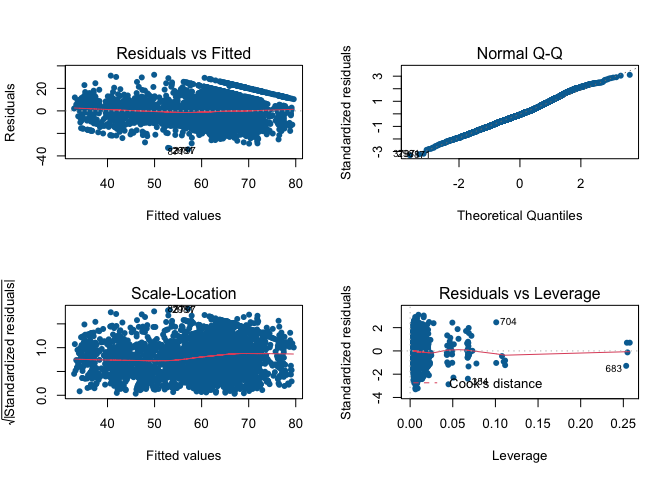

```r
par(mfrow=c(2,2))
plot(lm_fit$fit, pch = 16, col = '#006EA1')
```

```r
# Data frame of estimated coefficients
tidy(lm_fit)
```

```
## # A tibble: 26 × 5
##    term                           estimate std.error statistic   p.value
##    <chr>                             <dbl>     <dbl>     <dbl>     <dbl>
##  1 (Intercept)                      45.5      1.79      25.4   5.01e-130
##  2 age                               0.151    0.0620     2.44  1.48e-  2
##  3 age_7cat25-34                    -3.22     1.01      -3.20  1.40e-  3
##  4 age_7cat35-44                    -5.45     1.44      -3.79  1.50e-  4
##  5 age_7cat45-54                    -5.78     1.98      -2.92  3.53e-  3
##  6 age_7cat55-64                    -6.40     2.50      -2.56  1.06e-  2
##  7 age_7cat65-74                    -3.13     3.07      -1.02  3.08e-  1
##  8 age_7cat75+                      -3.38     3.72      -0.909 3.63e-  1
##  9 econ_saving$1,000,000 or more     7.32     0.810      9.04  2.63e- 19
## 10 econ_saving$100,000 - $249,999    1.21     0.695      1.74  8.22e-  2
## # … with 16 more rows
```

```r
# Performance metrics on training data
glance(lm_fit)
```

```
## # A tibble: 1 × 12
##   r.squared adj.r.squared sigma statistic p.value    df  logLik    AIC    BIC
##       <dbl>         <dbl> <dbl>     <dbl>   <dbl> <dbl>   <dbl>  <dbl>  <dbl>
## 1     0.485         0.481  10.4      119.       0    25 -12011. 24076. 24240.
## # … with 3 more variables: deviance <dbl>, df.residual <int>, nobs <int>
```

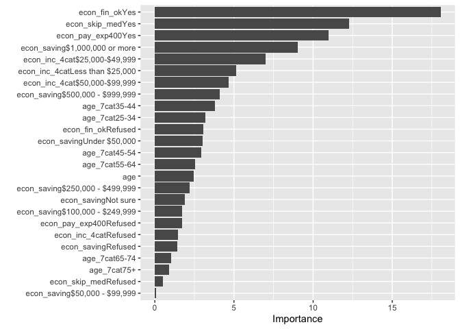

```r
# variable importance
vip(lm_fit, num_features=25)
```

```r
#predict(lm_fit, new_data = fed_test)

fed_results <- predict(lm_fit, new_data = fed_test) %>%
                            bind_cols(fed_test)

fed_results
```

```
## # A tibble: 801 × 9
##    .pred cfpb_score   age age_7cat econ_saving       econ_inc_4cat   econ_fin_ok
##    <dbl>      <int> <int> <fct>    <fct>             <fct>           <fct>
##  1  64.4         51    45 45-54    "$100,000 - $249… $100,000 or mo… Yes
##  2  45.7         41    43 35-44    ""                $100,000 or mo… No
##  3  68.3         90    78 75+      "$50,000 - $99,9… $50,000-$99,999 Yes
##  4  60.7         82    27 25-34    "$50,000 - $99,9… $50,000-$99,999 Yes
##  5  42.4         40    55 55-64    "Under $50,000"   Less than $25,… No
##  6  57.3         57    38 35-44    "Refused"         $100,000 or mo… Yes
##  7  43.8         44    64 55-64    "Under $50,000"   Less than $25,… No
##  8  77.4         70    73 65-74    "$1,000,000 or m… $100,000 or mo… Yes
##  9  77.6         90    74 65-74    "$1,000,000 or m… $100,000 or mo… Yes
## 10  59.5         64    64 55-64    "Under $50,000"   $25,000-$49,999 Yes
## # … with 791 more rows, and 2 more variables: econ_pay_exp400 <fct>,
## #   econ_skip_med <fct>
```

```r
# RMSE on test set
rmse(fed_results, truth = cfpb_score, estimate = .pred)
```

```
## # A tibble: 1 × 3
##   .metric .estimator .estimate
##   <chr>   <chr>          <dbl>
## 1 rmse    standard        10.6
```

```r
rsq(fed_results, truth = cfpb_score, estimate = .pred)
```

```
## # A tibble: 1 × 3
##   .metric .estimator .estimate
##   <chr>   <chr>          <dbl>
## 1 rsq     standard       0.469
```

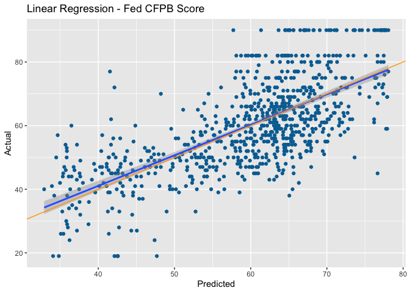

```r
ggplot(data = fed_results,
       mapping = aes(x = .pred, y = cfpb_score)) +
  geom_point(color = '#006EA1') +
  geom_smooth(method = lm) +
  geom_abline(intercept = 0, slope = 1, color = 'orange') +
  labs(title = 'Linear Regression - Fed CFPB Score',
       x = 'Predicted',
       y = 'Actual')
```

- classifications
- regression
- machine learning
- backwards selection and p-values
- forward selection and p-values

# iNterpret

- draw conclusions
- evaluate meaning of results

backwards and forwards approaches to optimizing models - balance predictive power with complexity. Reduce the number of variable included in the model.

# Challenges

- understanding the data
- filtering through the volume
- transforming and tiddying the data for each model type
- loading tensor flow packages
- tuning the models
- unravel the complexity of the surveys used - include weighted population data

# Conclusion

- The linear regression model was the most effective with this analysis
- Impacted by my understanding of the data. more exposure to the data would enable greater configuration of the machine learnig models and neural network and could potentially improve the analysis

The most effective model was the linear regression model.

Determined by the explanitor of the model.